# Risk Factor Analysis

## Outcome Variable

**Outcome Variable:** wast_rec90d

## Predictor Variables

**Intervention Variable:** perdiar6

**Adjustment Set:**

unadjusted

## Stratifying Variables

The analysis was stratified on these variable(s):

- agecat
- studyid
- country

## Data Summary

| agecat | studyid | country | perdiar6 | wast_rec90d | n_cell | n |
| --- | --- | --- | --- | --- | --- | --- |
| 0-24 months | ki0047075b-MAL-ED | BANGLADESH | (0%, 5%] | 0 | 20 | 124 |
| 0-24 months | ki0047075b-MAL-ED | BANGLADESH | (0%, 5%] | 1 | 34 | 124 |
| 0-24 months | ki0047075b-MAL-ED | BANGLADESH | 0% | 0 | 17 | 124 |
| 0-24 months | ki0047075b-MAL-ED | BANGLADESH | 0% | 1 | 21 | 124 |
| 0-24 months | ki0047075b-MAL-ED | BANGLADESH | >5% | 0 | 8 | 124 |
| 0-24 months | ki0047075b-MAL-ED | BANGLADESH | >5% | 1 | 24 | 124 |
| 0-24 months | ki0047075b-MAL-ED | BRAZIL | (0%, 5%] | 0 | 0 | 23 |
| 0-24 months | ki0047075b-MAL-ED | BRAZIL | (0%, 5%] | 1 | 2 | 23 |
| 0-24 months | ki0047075b-MAL-ED | BRAZIL | 0% | 0 | 5 | 23 |
| 0-24 months | ki0047075b-MAL-ED | BRAZIL | 0% | 1 | 15 | 23 |
| 0-24 months | ki0047075b-MAL-ED | BRAZIL | >5% | 0 | 1 | 23 |
| 0-24 months | ki0047075b-MAL-ED | BRAZIL | >5% | 1 | 0 | 23 |
| 0-24 months | ki0047075b-MAL-ED | INDIA | (0%, 5%] | 0 | 35 | 178 |
| 0-24 months | ki0047075b-MAL-ED | INDIA | (0%, 5%] | 1 | 48 | 178 |
| 0-24 months | ki0047075b-MAL-ED | INDIA | 0% | 0 | 14 | 178 |
| 0-24 months | ki0047075b-MAL-ED | INDIA | 0% | 1 | 28 | 178 |
| 0-24 months | ki0047075b-MAL-ED | INDIA | >5% | 0 | 22 | 178 |
| 0-24 months | ki0047075b-MAL-ED | INDIA | >5% | 1 | 31 | 178 |
| 0-24 months | ki0047075b-MAL-ED | NEPAL | (0%, 5%] | 0 | 2 | 93 |
| 0-24 months | ki0047075b-MAL-ED | NEPAL | (0%, 5%] | 1 | 21 | 93 |
| 0-24 months | ki0047075b-MAL-ED | NEPAL | 0% | 0 | 12 | 93 |
| 0-24 months | ki0047075b-MAL-ED | NEPAL | 0% | 1 | 30 | 93 |
| 0-24 months | ki0047075b-MAL-ED | NEPAL | >5% | 0 | 6 | 93 |
| 0-24 months | ki0047075b-MAL-ED | NEPAL | >5% | 1 | 22 | 93 |
| 0-24 months | ki0047075b-MAL-ED | PERU | (0%, 5%] | 0 | 1 | 34 |
| 0-24 months | ki0047075b-MAL-ED | PERU | (0%, 5%] | 1 | 6 | 34 |
| 0-24 months | ki0047075b-MAL-ED | PERU | 0% | 0 | 3 | 34 |
| 0-24 months | ki0047075b-MAL-ED | PERU | 0% | 1 | 8 | 34 |
| 0-24 months | ki0047075b-MAL-ED | PERU | >5% | 0 | 2 | 34 |
| 0-24 months | ki0047075b-MAL-ED | PERU | >5% | 1 | 14 | 34 |

[output cut: 258 more lines]

The following strata were considered:

- agecat: 0-24 months, studyid: ki0047075b-MAL-ED, country: BANGLADESH
- agecat: 0-24 months, studyid: ki0047075b-MAL-ED, country: BRAZIL
- agecat: 0-24 months, studyid: ki0047075b-MAL-ED, country: INDIA
- agecat: 0-24 months, studyid: ki0047075b-MAL-ED, country: NEPAL
- agecat: 0-24 months, studyid: ki0047075b-MAL-ED, country: PERU
- agecat: 0-24 months, studyid: ki0047075b-MAL-ED, country: SOUTH AFRICA
- agecat: 0-24 months, studyid: ki0047075b-MAL-ED, country: TANZANIA, UNITED REPUBLIC OF
- agecat: 0-24 months, studyid: ki1000109-ResPak, country: PAKISTAN
- agecat: 0-24 months, studyid: ki1017093-NIH-Birth, country: BANGLADESH
- agecat: 0-24 months, studyid: ki1017093b-PROVIDE, country: BANGLADESH
- agecat: 0-24 months, studyid: ki1017093c-NIH-Crypto, country: BANGLADESH
- agecat: 0-24 months, studyid: ki1114097-CMIN, country: BANGLADESH
- agecat: 0-24 months, studyid: ki1114097-CMIN, country: BRAZIL
- agecat: 0-24 months, studyid: ki1114097-CMIN, country: GUINEA-BISSAU
- agecat: 0-24 months, studyid: ki1114097-CMIN, country: PERU
- agecat: 0-24 months, studyid: ki1114097-CONTENT, country: PERU
- agecat: 0-6 months, studyid: ki0047075b-MAL-ED, country: BANGLADESH
- agecat: 0-6 months, studyid: ki0047075b-MAL-ED, country: BRAZIL
- agecat: 0-6 months, studyid: ki0047075b-MAL-ED, country: INDIA
- agecat: 0-6 months, studyid: ki0047075b-MAL-ED, country: NEPAL
- agecat: 0-6 months, studyid: ki0047075b-MAL-ED, country: PERU
- agecat: 0-6 months, studyid: ki0047075b-MAL-ED, country: SOUTH AFRICA
- agecat: 0-6 months, studyid: ki0047075b-MAL-ED, country: TANZANIA, UNITED REPUBLIC OF
- agecat: 0-6 months, studyid: ki1000109-ResPak, country: PAKISTAN
- agecat: 0-6 months, studyid: ki1017093-NIH-Birth, country: BANGLADESH
- agecat: 0-6 months, studyid: ki1017093b-PROVIDE, country: BANGLADESH
- agecat: 0-6 months, studyid: ki1017093c-NIH-Crypto, country: BANGLADESH
- agecat: 0-6 months, studyid: ki1114097-CMIN, country: BANGLADESH
- agecat: 0-6 months, studyid: ki1114097-CMIN, country: BRAZIL
- agecat: 0-6 months, studyid: ki1114097-CMIN, country: GUINEA-BISSAU
- agecat: 0-6 months, studyid: ki1114097-CMIN, country: PERU
- agecat: 0-6 months, studyid: ki1114097-CONTENT, country: PERU
- agecat: 6-24 months, studyid: ki0047075b-MAL-ED, country: BANGLADESH
- agecat: 6-24 months, studyid: ki0047075b-MAL-ED, country: BRAZIL
- agecat: 6-24 months, studyid: ki0047075b-MAL-ED, country: INDIA
- agecat: 6-24 months, studyid: ki0047075b-MAL-ED, country: NEPAL
- agecat: 6-24 months, studyid: ki0047075b-MAL-ED, country: PERU
- agecat: 6-24 months, studyid: ki0047075b-MAL-ED, country: SOUTH AFRICA
- agecat: 6-24 months, studyid: ki0047075b-MAL-ED, country: TANZANIA, UNITED REPUBLIC OF
- agecat: 6-24 months, studyid: ki1000109-ResPak, country: PAKISTAN
- agecat: 6-24 months, studyid: ki1017093-NIH-Birth, country: BANGLADESH
- agecat: 6-24 months, studyid: ki1017093b-PROVIDE, country: BANGLADESH
- agecat: 6-24 months, studyid: ki1017093c-NIH-Crypto, country: BANGLADESH
- agecat: 6-24 months, studyid: ki1114097-CMIN, country: BANGLADESH
- agecat: 6-24 months, studyid: ki1114097-CMIN, country: BRAZIL
- agecat: 6-24 months, studyid: ki1114097-CMIN, country: GUINEA-BISSAU
- agecat: 6-24 months, studyid: ki1114097-CMIN, country: PERU
- agecat: 6-24 months, studyid: ki1114097-CONTENT, country: PERU

### Dropped Strata

Some strata were dropped due to rare outcomes:

- agecat: 0-24 months, studyid: ki0047075b-MAL-ED, country: BRAZIL
- agecat: 0-24 months, studyid: ki0047075b-MAL-ED, country: NEPAL
- agecat: 0-24 months, studyid: ki0047075b-MAL-ED, country: PERU
- agecat: 0-24 months, studyid: ki0047075b-MAL-ED, country: SOUTH AFRICA
- agecat: 0-24 months, studyid: ki0047075b-MAL-ED, country: TANZANIA, UNITED REPUBLIC OF
- agecat: 0-24 months, studyid: ki1114097-CMIN, country: BRAZIL
- agecat: 0-24 months, studyid: ki1114097-CMIN, country: PERU
- agecat: 0-24 months, studyid: ki1114097-CONTENT, country: PERU
- agecat: 0-6 months, studyid: ki0047075b-MAL-ED, country: BANGLADESH
- agecat: 0-6 months, studyid: ki0047075b-MAL-ED, country: BRAZIL
- agecat: 0-6 months, studyid: ki0047075b-MAL-ED, country: NEPAL
- agecat: 0-6 months, studyid: ki0047075b-MAL-ED, country: PERU
- agecat: 0-6 months, studyid: ki0047075b-MAL-ED, country: SOUTH AFRICA
- agecat: 0-6 months, studyid: ki0047075b-MAL-ED, country: TANZANIA, UNITED REPUBLIC OF
- agecat: 0-6 months, studyid: ki1114097-CMIN, country: BRAZIL
- agecat: 0-6 months, studyid: ki1114097-CMIN, country: GUINEA-BISSAU
- agecat: 0-6 months, studyid: ki1114097-CMIN, country: PERU
- agecat: 0-6 months, studyid: ki1114097-CONTENT, country: PERU
- agecat: 6-24 months, studyid: ki0047075b-MAL-ED, country: BRAZIL
- agecat: 6-24 months, studyid: ki0047075b-MAL-ED, country: NEPAL
- agecat: 6-24 months, studyid: ki0047075b-MAL-ED, country: PERU
- agecat: 6-24 months, studyid: ki0047075b-MAL-ED, country: SOUTH AFRICA
- agecat: 6-24 months, studyid: ki0047075b-MAL-ED, country: TANZANIA, UNITED REPUBLIC OF
- agecat: 6-24 months, studyid: ki1000109-ResPak, country: PAKISTAN
- agecat: 6-24 months, studyid: ki1017093c-NIH-Crypto, country: BANGLADESH
- agecat: 6-24 months, studyid: ki1114097-CMIN, country: BRAZIL
- agecat: 6-24 months, studyid: ki1114097-CMIN, country: PERU
- agecat: 6-24 months, studyid: ki1114097-CONTENT, country: PERU

## Methods Detail

We’re interested in the causal parameters $E[Y_a]$ for all values of $a \in \mathcal{A}$. These parameters represent the mean outcome if, possibly contrary to fact, we intervened to set all units to have $A=a$. Under the randomization and positivity assumptions, these are identified by the statistical parameters $\psi_a=E_W[E_{Y|A,W}(Y|A=a,W)]$. In addition, we’re interested in the mean of $Y$, $E[Y]$ under no intervention (the observed mean). We will estimate these parameters by using SuperLearner to fit the relevant likelihood factors – $E_{Y|A,W}(Y|A=a,W)$ and $p(A=a|W)$, and then updating our likelihood fit using a joint TMLE.

For unadjusted analyses ($W=\{\}$), initial likelihoods were estimated using Lrnr_glm to estimate the simple $E(Y|A)$ and Lrnr_mean to estimate $p(A)$. For adjusted analyses, a small library containing Lrnr_glmnet, Lrnr_xgboost, and Lrnr_mean was used.

Having estimated these parameters, we will then use the delta method to estimate relative risks and attributable risks relative to a prespecified baseline level of $A$.

# Results Detail

## Results Plots

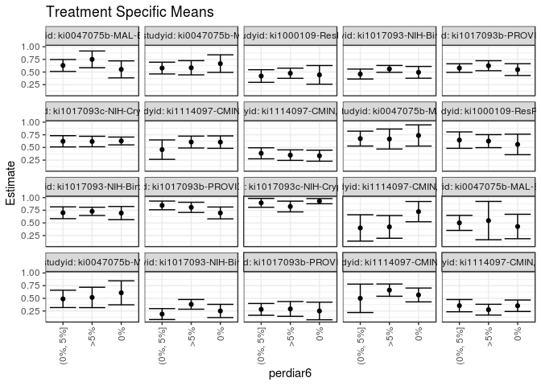

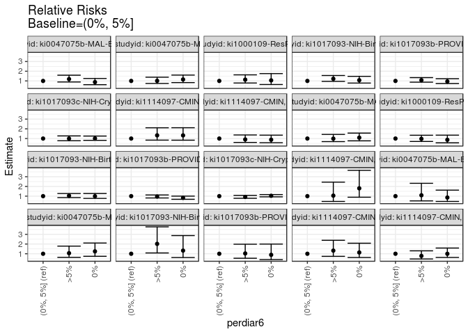

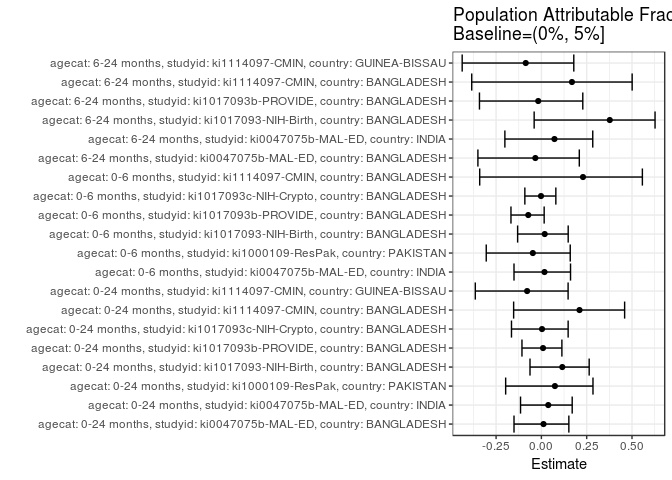

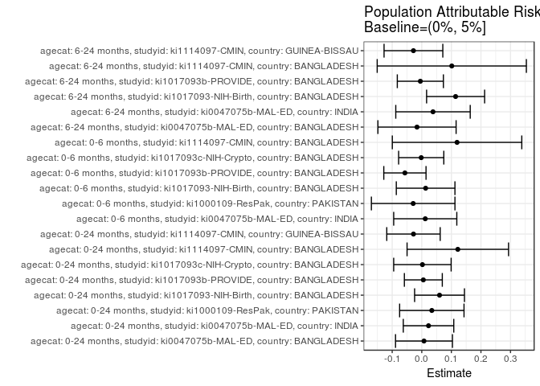

## Results Table

### Parameter: TSM

| agecat | studyid | country | intervention_level | baseline_level | estimate | ci_lower | ci_upper |
| --- | --- | --- | --- | --- | --- | --- | --- |
| 0-24 months | ki0047075b-MAL-ED | BANGLADESH | (0%, 5%] | NA | 0.6296296 | 0.5121519 | 0.7471074 |
| 0-24 months | ki0047075b-MAL-ED | BANGLADESH | 0% | NA | 0.5526316 | 0.3844057 | 0.7208575 |
| 0-24 months | ki0047075b-MAL-ED | BANGLADESH | >5% | NA | 0.7500000 | 0.5844253 | 0.9155747 |
| 0-24 months | ki0047075b-MAL-ED | INDIA | (0%, 5%] | NA | 0.5783133 | 0.4621766 | 0.6944499 |
| 0-24 months | ki0047075b-MAL-ED | INDIA | 0% | NA | 0.6666667 | 0.4928234 | 0.8405099 |
| 0-24 months | ki0047075b-MAL-ED | INDIA | >5% | NA | 0.5849057 | 0.4443908 | 0.7254205 |
| 0-24 months | ki1000109-ResPak | PAKISTAN | (0%, 5%] | NA | 0.4210526 | 0.2966327 | 0.5454726 |
| 0-24 months | ki1000109-ResPak | PAKISTAN | 0% | NA | 0.4444444 | 0.2599608 | 0.6289281 |
| 0-24 months | ki1000109-ResPak | PAKISTAN | >5% | NA | 0.4766355 | 0.3765906 | 0.5766804 |
| 0-24 months | ki1017093-NIH-Birth | BANGLADESH | (0%, 5%] | NA | 0.4601770 | 0.3619611 | 0.5583929 |
| 0-24 months | ki1017093-NIH-Birth | BANGLADESH | 0% | NA | 0.4943820 | 0.3785619 | 0.6102021 |
| 0-24 months | ki1017093-NIH-Birth | BANGLADESH | >5% | NA | 0.5616438 | 0.4935175 | 0.6297702 |
| 0-24 months | ki1017093b-PROVIDE | BANGLADESH | (0%, 5%] | NA | 0.5777778 | 0.4928046 | 0.6627510 |
| 0-24 months | ki1017093b-PROVIDE | BANGLADESH | 0% | NA | 0.5476190 | 0.4310129 | 0.6642251 |
| 0-24 months | ki1017093b-PROVIDE | BANGLADESH | >5% | NA | 0.6250000 | 0.5264084 | 0.7235916 |
| 0-24 months | ki1017093c-NIH-Crypto | BANGLADESH | (0%, 5%] | NA | 0.6216216 | 0.5106002 | 0.7326431 |
| 0-24 months | ki1017093c-NIH-Crypto | BANGLADESH | 0% | NA | 0.6282051 | 0.5508612 | 0.7055491 |
| 0-24 months | ki1017093c-NIH-Crypto | BANGLADESH | >5% | NA | 0.6172840 | 0.5136710 | 0.7208969 |
| 0-24 months | ki1114097-CMIN | BANGLADESH | (0%, 5%] | NA | 0.4571429 | 0.2650448 | 0.6492409 |
| 0-24 months | ki1114097-CMIN | BANGLADESH | 0% | NA | 0.6056338 | 0.4830890 | 0.7281786 |
| 0-24 months | ki1114097-CMIN | BANGLADESH | >5% | NA | 0.6071429 | 0.4897119 | 0.7245738 |
| 0-24 months | ki1114097-CMIN | GUINEA-BISSAU | (0%, 5%] | NA | 0.3846154 | 0.2753643 | 0.4938664 |
| 0-24 months | ki1114097-CMIN | GUINEA-BISSAU | 0% | NA | 0.3376623 | 0.2286734 | 0.4466513 |
| 0-24 months | ki1114097-CMIN | GUINEA-BISSAU | >5% | NA | 0.3483146 | 0.2445994 | 0.4520299 |
| 0-6 months | ki0047075b-MAL-ED | INDIA | (0%, 5%] | NA | 0.6750000 | 0.5281850 | 0.8218150 |
| 0-6 months | ki0047075b-MAL-ED | INDIA | 0% | NA | 0.7368421 | 0.5274868 | 0.9461974 |
| 0-6 months | ki0047075b-MAL-ED | INDIA | >5% | NA | 0.6666667 | 0.4693684 | 0.8639649 |
| 0-6 months | ki1000109-ResPak | PAKISTAN | (0%, 5%] | NA | 0.6451613 | 0.4830861 | 0.8072365 |
| 0-6 months | ki1000109-ResPak | PAKISTAN | 0% | NA | 0.5600000 | 0.3572725 | 0.7627275 |
| 0-6 months | ki1000109-ResPak | PAKISTAN | >5% | NA | 0.6250000 | 0.4962416 | 0.7537584 |
| 0-6 months | ki1017093-NIH-Birth | BANGLADESH | (0%, 5%] | NA | 0.7000000 | 0.5832614 | 0.8167386 |
| 0-6 months | ki1017093-NIH-Birth | BANGLADESH | 0% | NA | 0.6938776 | 0.5639590 | 0.8237961 |
| 0-6 months | ki1017093-NIH-Birth | BANGLADESH | >5% | NA | 0.7280702 | 0.6468500 | 0.8092903 |
| 0-6 months | ki1017093b-PROVIDE | BANGLADESH | (0%, 5%] | NA | 0.8450704 | 0.7592729 | 0.9308680 |
| 0-6 months | ki1017093b-PROVIDE | BANGLADESH | 0% | NA | 0.6964286 | 0.5793887 | 0.8134685 |
| 0-6 months | ki1017093b-PROVIDE | BANGLADESH | >5% | NA | 0.8070175 | 0.7061401 | 0.9078950 |
| 0-6 months | ki1017093c-NIH-Crypto | BANGLADESH | (0%, 5%] | NA | 0.8958333 | 0.8083097 | 0.9833570 |
| 0-6 months | ki1017093c-NIH-Crypto | BANGLADESH | 0% | NA | 0.9292929 | 0.8781930 | 0.9803929 |
| 0-6 months | ki1017093c-NIH-Crypto | BANGLADESH | >5% | NA | 0.8235294 | 0.7175654 | 0.9294935 |
| 0-6 months | ki1114097-CMIN | BANGLADESH | (0%, 5%] | NA | 0.4000000 | 0.1395476 | 0.6604524 |
| 0-6 months | ki1114097-CMIN | BANGLADESH | 0% | NA | 0.7222222 | 0.5220936 | 0.9223508 |
| 0-6 months | ki1114097-CMIN | BANGLADESH | >5% | NA | 0.4210526 | 0.1965983 | 0.6455070 |
| 6-24 months | ki0047075b-MAL-ED | BANGLADESH | (0%, 5%] | NA | 0.5000000 | 0.3511323 | 0.6488677 |
| 6-24 months | ki0047075b-MAL-ED | BANGLADESH | 0% | NA | 0.4285714 | 0.1873815 | 0.6697613 |
| 6-24 months | ki0047075b-MAL-ED | BANGLADESH | >5% | NA | 0.5454545 | 0.1667926 | 0.9241165 |
| 6-24 months | ki0047075b-MAL-ED | INDIA | (0%, 5%] | NA | 0.4883721 | 0.3173946 | 0.6593495 |
| 6-24 months | ki0047075b-MAL-ED | INDIA | 0% | NA | 0.6086957 | 0.3716126 | 0.8457787 |
| 6-24 months | ki0047075b-MAL-ED | INDIA | >5% | NA | 0.5172414 | 0.3159219 | 0.7185608 |
| 6-24 months | ki1017093-NIH-Birth | BANGLADESH | (0%, 5%] | NA | 0.1886792 | 0.0809763 | 0.2963822 |
| 6-24 months | ki1017093-NIH-Birth | BANGLADESH | 0% | NA | 0.2500000 | 0.1193951 | 0.3806049 |
| 6-24 months | ki1017093-NIH-Birth | BANGLADESH | >5% | NA | 0.3809524 | 0.2849146 | 0.4769902 |
| 6-24 months | ki1017093b-PROVIDE | BANGLADESH | (0%, 5%] | NA | 0.2812500 | 0.1643962 | 0.3981038 |
| 6-24 months | ki1017093b-PROVIDE | BANGLADESH | 0% | NA | 0.2500000 | 0.0764031 | 0.4235969 |
| 6-24 months | ki1017093b-PROVIDE | BANGLADESH | >5% | NA | 0.2903226 | 0.1444416 | 0.4362035 |
| 6-24 months | ki1114097-CMIN | BANGLADESH | (0%, 5%] | NA | 0.5000000 | 0.2197112 | 0.7802888 |
| 6-24 months | ki1114097-CMIN | BANGLADESH | 0% | NA | 0.5660377 | 0.4292281 | 0.7028474 |
| 6-24 months | ki1114097-CMIN | BANGLADESH | >5% | NA | 0.6615385 | 0.5406406 | 0.7824363 |
| 6-24 months | ki1114097-CMIN | GUINEA-BISSAU | (0%, 5%] | NA | 0.3548387 | 0.2338965 | 0.4757809 |
| 6-24 months | ki1114097-CMIN | GUINEA-BISSAU | 0% | NA | 0.3529412 | 0.2396149 | 0.4662674 |
| 6-24 months | ki1114097-CMIN | GUINEA-BISSAU | >5% | NA | 0.2753623 | 0.1684231 | 0.3823015 |

### Parameter: E(Y)

| agecat | studyid | country | intervention_level | baseline_level | estimate | ci_lower | ci_upper |
| --- | --- | --- | --- | --- | --- | --- | --- |
| 0-24 months | ki0047075b-MAL-ED | BANGLADESH | NA | NA | 0.6370968 | 0.5511492 | 0.7230443 |
| 0-24 months | ki0047075b-MAL-ED | INDIA | NA | NA | 0.6011236 | 0.5212729 | 0.6809743 |
| 0-24 months | ki1000109-ResPak | PAKISTAN | NA | NA | 0.4550000 | 0.3826235 | 0.5273765 |
| 0-24 months | ki1017093-NIH-Birth | BANGLADESH | NA | NA | 0.5201900 | 0.4695846 | 0.5707955 |
| 0-24 months | ki1017093b-PROVIDE | BANGLADESH | NA | NA | 0.5830619 | 0.5262762 | 0.6398476 |
| 0-24 months | ki1017093c-NIH-Crypto | BANGLADESH | NA | NA | 0.6237942 | 0.5698223 | 0.6777662 |
| 0-24 months | ki1114097-CMIN | BANGLADESH | NA | NA | 0.5789474 | 0.5004470 | 0.6574477 |
| 0-24 months | ki1114097-CMIN | GUINEA-BISSAU | NA | NA | 0.3565574 | 0.2946037 | 0.4185110 |
| 0-6 months | ki0047075b-MAL-ED | INDIA | NA | NA | 0.6867470 | 0.5837430 | 0.7897510 |
| 0-6 months | ki1000109-ResPak | PAKISTAN | NA | NA | 0.6160714 | 0.5252688 | 0.7068741 |
| 0-6 months | ki1017093-NIH-Birth | BANGLADESH | NA | NA | 0.7130045 | 0.6535890 | 0.7724200 |
| 0-6 months | ki1017093b-PROVIDE | BANGLADESH | NA | NA | 0.7880435 | 0.7295878 | 0.8464992 |
| 0-6 months | ki1017093c-NIH-Crypto | BANGLADESH | NA | NA | 0.8939394 | 0.8505280 | 0.9373508 |
| 0-6 months | ki1114097-CMIN | BANGLADESH | NA | NA | 0.5192308 | 0.3806687 | 0.6577929 |
| 6-24 months | ki0047075b-MAL-ED | BANGLADESH | NA | NA | 0.4838710 | 0.3544124 | 0.6133295 |
| 6-24 months | ki0047075b-MAL-ED | INDIA | NA | NA | 0.5263158 | 0.4116286 | 0.6410029 |
| 6-24 months | ki1017093-NIH-Birth | BANGLADESH | NA | NA | 0.3030303 | 0.2377927 | 0.3682679 |
| 6-24 months | ki1017093b-PROVIDE | BANGLADESH | NA | NA | 0.2764228 | 0.1950773 | 0.3577682 |
| 6-24 months | ki1114097-CMIN | BANGLADESH | NA | NA | 0.6014493 | 0.5131344 | 0.6897641 |
| 6-24 months | ki1114097-CMIN | GUINEA-BISSAU | NA | NA | 0.3266332 | 0.2609581 | 0.3923082 |

### Parameter: RR

| agecat | studyid | country | intervention_level | baseline_level | estimate | ci_lower | ci_upper |
| --- | --- | --- | --- | --- | --- | --- | --- |
| 0-24 months | ki0047075b-MAL-ED | BANGLADESH | (0%, 5%] | (0%, 5%] | 1.0000000 | 1.0000000 | 1.000000 |
| 0-24 months | ki0047075b-MAL-ED | BANGLADESH | 0% | (0%, 5%] | 0.8777090 | 0.6140845 | 1.254507 |
| 0-24 months | ki0047075b-MAL-ED | BANGLADESH | >5% | (0%, 5%] | 1.1911765 | 0.8917408 | 1.591159 |
| 0-24 months | ki0047075b-MAL-ED | INDIA | (0%, 5%] | (0%, 5%] | 1.0000000 | 1.0000000 | 1.000000 |
| 0-24 months | ki0047075b-MAL-ED | INDIA | 0% | (0%, 5%] | 1.1527778 | 0.8294716 | 1.602100 |
| 0-24 months | ki0047075b-MAL-ED | INDIA | >5% | (0%, 5%] | 1.0113994 | 0.7395011 | 1.383269 |
| 0-24 months | ki1000109-ResPak | PAKISTAN | (0%, 5%] | (0%, 5%] | 1.0000000 | 1.0000000 | 1.000000 |
| 0-24 months | ki1000109-ResPak | PAKISTAN | 0% | (0%, 5%] | 1.0555555 | 0.6342078 | 1.756833 |
| 0-24 months | ki1000109-ResPak | PAKISTAN | >5% | (0%, 5%] | 1.1320093 | 0.7874565 | 1.627322 |
| 0-24 months | ki1017093-NIH-Birth | BANGLADESH | (0%, 5%] | (0%, 5%] | 1.0000000 | 1.0000000 | 1.000000 |
| 0-24 months | ki1017093-NIH-Birth | BANGLADESH | 0% | (0%, 5%] | 1.0743302 | 0.7824282 | 1.475133 |
| 0-24 months | ki1017093-NIH-Birth | BANGLADESH | >5% | (0%, 5%] | 1.2204953 | 0.9547275 | 1.560245 |
| 0-24 months | ki1017093b-PROVIDE | BANGLADESH | (0%, 5%] | (0%, 5%] | 1.0000000 | 1.0000000 | 1.000000 |
| 0-24 months | ki1017093b-PROVIDE | BANGLADESH | 0% | (0%, 5%] | 0.9478022 | 0.7316206 | 1.227862 |
| 0-24 months | ki1017093b-PROVIDE | BANGLADESH | >5% | (0%, 5%] | 1.0817308 | 0.8717498 | 1.342291 |
| 0-24 months | ki1017093c-NIH-Crypto | BANGLADESH | (0%, 5%] | (0%, 5%] | 1.0000000 | 1.0000000 | 1.000000 |
| 0-24 months | ki1017093c-NIH-Crypto | BANGLADESH | 0% | (0%, 5%] | 1.0105909 | 0.8131899 | 1.255911 |
| 0-24 months | ki1017093c-NIH-Crypto | BANGLADESH | >5% | (0%, 5%] | 0.9930220 | 0.7768535 | 1.269342 |
| 0-24 months | ki1114097-CMIN | BANGLADESH | (0%, 5%] | (0%, 5%] | 1.0000000 | 1.0000000 | 1.000000 |
| 0-24 months | ki1114097-CMIN | BANGLADESH | 0% | (0%, 5%] | 1.3248239 | 0.8310210 | 2.112051 |
| 0-24 months | ki1114097-CMIN | BANGLADESH | >5% | (0%, 5%] | 1.3281250 | 0.8362458 | 2.109327 |
| 0-24 months | ki1114097-CMIN | GUINEA-BISSAU | (0%, 5%] | (0%, 5%] | 1.0000000 | 1.0000000 | 1.000000 |
| 0-24 months | ki1114097-CMIN | GUINEA-BISSAU | 0% | (0%, 5%] | 0.8779221 | 0.5710802 | 1.349630 |
| 0-24 months | ki1114097-CMIN | GUINEA-BISSAU | >5% | (0%, 5%] | 0.9056180 | 0.6001887 | 1.366477 |
| 0-6 months | ki0047075b-MAL-ED | INDIA | (0%, 5%] | (0%, 5%] | 1.0000000 | 1.0000000 | 1.000000 |
| 0-6 months | ki0047075b-MAL-ED | INDIA | 0% | (0%, 5%] | 1.0916179 | 0.7632584 | 1.561240 |
| 0-6 months | ki0047075b-MAL-ED | INDIA | >5% | (0%, 5%] | 0.9876543 | 0.6840295 | 1.426051 |
| 0-6 months | ki1000109-ResPak | PAKISTAN | (0%, 5%] | (0%, 5%] | 1.0000000 | 1.0000000 | 1.000000 |
| 0-6 months | ki1000109-ResPak | PAKISTAN | 0% | (0%, 5%] | 0.8680000 | 0.5586661 | 1.348612 |
| 0-6 months | ki1000109-ResPak | PAKISTAN | >5% | (0%, 5%] | 0.9687500 | 0.7000364 | 1.340611 |
| 0-6 months | ki1017093-NIH-Birth | BANGLADESH | (0%, 5%] | (0%, 5%] | 1.0000000 | 1.0000000 | 1.000000 |
| 0-6 months | ki1017093-NIH-Birth | BANGLADESH | 0% | (0%, 5%] | 0.9912536 | 0.7714201 | 1.273734 |
| 0-6 months | ki1017093-NIH-Birth | BANGLADESH | >5% | (0%, 5%] | 1.0401003 | 0.8510168 | 1.271195 |
| 0-6 months | ki1017093b-PROVIDE | BANGLADESH | (0%, 5%] | (0%, 5%] | 1.0000000 | 1.0000000 | 1.000000 |
| 0-6 months | ki1017093b-PROVIDE | BANGLADESH | 0% | (0%, 5%] | 0.8241071 | 0.6771931 | 1.002894 |
| 0-6 months | ki1017093b-PROVIDE | BANGLADESH | >5% | (0%, 5%] | 0.9549708 | 0.8129292 | 1.121831 |
| 0-6 months | ki1017093c-NIH-Crypto | BANGLADESH | (0%, 5%] | (0%, 5%] | 1.0000000 | 1.0000000 | 1.000000 |
| 0-6 months | ki1017093c-NIH-Crypto | BANGLADESH | 0% | (0%, 5%] | 1.0373502 | 0.9273331 | 1.160420 |
| 0-6 months | ki1017093c-NIH-Crypto | BANGLADESH | >5% | (0%, 5%] | 0.9192886 | 0.7821451 | 1.080479 |
| 0-6 months | ki1114097-CMIN | BANGLADESH | (0%, 5%] | (0%, 5%] | 1.0000000 | 1.0000000 | 1.000000 |
| 0-6 months | ki1114097-CMIN | BANGLADESH | 0% | (0%, 5%] | 1.8055556 | 0.8897869 | 3.663833 |
| 0-6 months | ki1114097-CMIN | BANGLADESH | >5% | (0%, 5%] | 1.0526316 | 0.4537449 | 2.441974 |
| 6-24 months | ki0047075b-MAL-ED | BANGLADESH | (0%, 5%] | (0%, 5%] | 1.0000000 | 1.0000000 | 1.000000 |
| 6-24 months | ki0047075b-MAL-ED | BANGLADESH | 0% | (0%, 5%] | 0.8571429 | 0.4534671 | 1.620170 |
| 6-24 months | ki0047075b-MAL-ED | BANGLADESH | >5% | (0%, 5%] | 1.0909091 | 0.5125509 | 2.321882 |
| 6-24 months | ki0047075b-MAL-ED | INDIA | (0%, 5%] | (0%, 5%] | 1.0000000 | 1.0000000 | 1.000000 |
| 6-24 months | ki0047075b-MAL-ED | INDIA | 0% | (0%, 5%] | 1.2463768 | 0.7380692 | 2.104755 |
| 6-24 months | ki0047075b-MAL-ED | INDIA | >5% | (0%, 5%] | 1.0591133 | 0.6276318 | 1.787228 |
| 6-24 months | ki1017093-NIH-Birth | BANGLADESH | (0%, 5%] | (0%, 5%] | 1.0000000 | 1.0000000 | 1.000000 |
| 6-24 months | ki1017093-NIH-Birth | BANGLADESH | 0% | (0%, 5%] | 1.3250000 | 0.6110623 | 2.873070 |
| 6-24 months | ki1017093-NIH-Birth | BANGLADESH | >5% | (0%, 5%] | 2.0190476 | 1.0816626 | 3.768785 |
| 6-24 months | ki1017093b-PROVIDE | BANGLADESH | (0%, 5%] | (0%, 5%] | 1.0000000 | 1.0000000 | 1.000000 |
| 6-24 months | ki1017093b-PROVIDE | BANGLADESH | 0% | (0%, 5%] | 0.8888889 | 0.3957295 | 1.996625 |
| 6-24 months | ki1017093b-PROVIDE | BANGLADESH | >5% | (0%, 5%] | 1.0322581 | 0.5377822 | 1.981391 |
| 6-24 months | ki1114097-CMIN | BANGLADESH | (0%, 5%] | (0%, 5%] | 1.0000000 | 1.0000000 | 1.000000 |
| 6-24 months | ki1114097-CMIN | BANGLADESH | 0% | (0%, 5%] | 1.1320755 | 0.6148297 | 2.084471 |
| 6-24 months | ki1114097-CMIN | BANGLADESH | >5% | (0%, 5%] | 1.3230769 | 0.7337002 | 2.385896 |
| 6-24 months | ki1114097-CMIN | GUINEA-BISSAU | (0%, 5%] | (0%, 5%] | 1.0000000 | 1.0000000 | 1.000000 |
| 6-24 months | ki1114097-CMIN | GUINEA-BISSAU | 0% | (0%, 5%] | 0.9946524 | 0.6226769 | 1.588839 |
| 6-24 months | ki1114097-CMIN | GUINEA-BISSAU | >5% | (0%, 5%] | 0.7760211 | 0.4628577 | 1.301067 |

### Parameter: PAR

| agecat | studyid | country | intervention_level | baseline_level | estimate | ci_lower | ci_upper |
| --- | --- | --- | --- | --- | --- | --- | --- |
| 0-24 months | ki0047075b-MAL-ED | BANGLADESH | (0%, 5%] | NA | 0.0074671 | -0.0887245 | 0.1036588 |
| 0-24 months | ki0047075b-MAL-ED | INDIA | (0%, 5%] | NA | 0.0228103 | -0.0625370 | 0.1081577 |
| 0-24 months | ki1000109-ResPak | PAKISTAN | (0%, 5%] | NA | 0.0339474 | -0.0748812 | 0.1427759 |
| 0-24 months | ki1017093-NIH-Birth | BANGLADESH | (0%, 5%] | NA | 0.0600130 | -0.0242401 | 0.1442661 |
| 0-24 months | ki1017093b-PROVIDE | BANGLADESH | (0%, 5%] | NA | 0.0052841 | -0.0588119 | 0.0693801 |
| 0-24 months | ki1017093c-NIH-Crypto | BANGLADESH | (0%, 5%] | NA | 0.0021726 | -0.0949452 | 0.0992904 |
| 0-24 months | ki1114097-CMIN | BANGLADESH | (0%, 5%] | NA | 0.1218045 | -0.0497271 | 0.2933361 |
| 0-24 months | ki1114097-CMIN | GUINEA-BISSAU | (0%, 5%] | NA | -0.0280580 | -0.1183667 | 0.0622507 |
| 0-6 months | ki0047075b-MAL-ED | INDIA | (0%, 5%] | NA | 0.0117470 | -0.0949245 | 0.1184184 |
| 0-6 months | ki1000109-ResPak | PAKISTAN | (0%, 5%] | NA | -0.0290899 | -0.1703332 | 0.1121535 |
| 0-6 months | ki1017093-NIH-Birth | BANGLADESH | (0%, 5%] | NA | 0.0130045 | -0.0861151 | 0.1121241 |
| 0-6 months | ki1017093b-PROVIDE | BANGLADESH | (0%, 5%] | NA | -0.0570269 | -0.1284226 | 0.0143687 |
| 0-6 months | ki1017093c-NIH-Crypto | BANGLADESH | (0%, 5%] | NA | -0.0018939 | -0.0782536 | 0.0744658 |
| 0-6 months | ki1114097-CMIN | BANGLADESH | (0%, 5%] | NA | 0.1192308 | -0.0996278 | 0.3380893 |
| 6-24 months | ki0047075b-MAL-ED | BANGLADESH | (0%, 5%] | NA | -0.0161290 | -0.1483198 | 0.1160618 |
| 6-24 months | ki0047075b-MAL-ED | INDIA | (0%, 5%] | NA | 0.0379437 | -0.0879079 | 0.1637953 |
| 6-24 months | ki1017093-NIH-Birth | BANGLADESH | (0%, 5%] | NA | 0.1143511 | 0.0162826 | 0.2124195 |
| 6-24 months | ki1017093b-PROVIDE | BANGLADESH | (0%, 5%] | NA | -0.0048272 | -0.0827262 | 0.0730717 |
| 6-24 months | ki1114097-CMIN | BANGLADESH | (0%, 5%] | NA | 0.1014493 | -0.1507209 | 0.3536194 |
| 6-24 months | ki1114097-CMIN | GUINEA-BISSAU | (0%, 5%] | NA | -0.0282055 | -0.1275228 | 0.0711117 |

### Parameter: PAF

| agecat | studyid | country | intervention_level | baseline_level | estimate | ci_lower | ci_upper |
| --- | --- | --- | --- | --- | --- | --- | --- |
| 0-24 months | ki0047075b-MAL-ED | BANGLADESH | (0%, 5%] | NA | 0.0117206 | -0.1511006 | 0.1515110 |
| 0-24 months | ki0047075b-MAL-ED | INDIA | (0%, 5%] | NA | 0.0379462 | -0.1150749 | 0.1699682 |
| 0-24 months | ki1000109-ResPak | PAKISTAN | (0%, 5%] | NA | 0.0746096 | -0.1971463 | 0.2846760 |
| 0-24 months | ki1017093-NIH-Birth | BANGLADESH | (0%, 5%] | NA | 0.1153675 | -0.0628192 | 0.2636804 |
| 0-24 months | ki1017093b-PROVIDE | BANGLADESH | (0%, 5%] | NA | 0.0090627 | -0.1071855 | 0.1131055 |
| 0-24 months | ki1017093c-NIH-Crypto | BANGLADESH | (0%, 5%] | NA | 0.0034829 | -0.1650265 | 0.1476190 |
| 0-24 months | ki1114097-CMIN | BANGLADESH | (0%, 5%] | NA | 0.2103896 | -0.1531514 | 0.4593212 |
| 0-24 months | ki1114097-CMIN | GUINEA-BISSAU | (0%, 5%] | NA | -0.0786914 | -0.3647331 | 0.1473972 |
| 0-6 months | ki0047075b-MAL-ED | INDIA | (0%, 5%] | NA | 0.0171053 | -0.1511351 | 0.1607570 |
| 0-6 months | ki1000109-ResPak | PAKISTAN | (0%, 5%] | NA | -0.0472183 | -0.3042964 | 0.1591894 |
| 0-6 months | ki1017093-NIH-Birth | BANGLADESH | (0%, 5%] | NA | 0.0182390 | -0.1311518 | 0.1478998 |
| 0-6 months | ki1017093b-PROVIDE | BANGLADESH | (0%, 5%] | NA | -0.0723652 | -0.1678767 | 0.0153351 |
| 0-6 months | ki1017093c-NIH-Crypto | BANGLADESH | (0%, 5%] | NA | -0.0021186 | -0.0912852 | 0.0797623 |
| 0-6 months | ki1114097-CMIN | BANGLADESH | (0%, 5%] | NA | 0.2296296 | -0.3404027 | 0.5572446 |
| 6-24 months | ki0047075b-MAL-ED | BANGLADESH | (0%, 5%] | NA | -0.0333333 | -0.3503145 | 0.2092377 |
| 6-24 months | ki0047075b-MAL-ED | INDIA | (0%, 5%] | NA | 0.0720930 | -0.2014981 | 0.2833851 |
| 6-24 months | ki1017093-NIH-Birth | BANGLADESH | (0%, 5%] | NA | 0.3773585 | -0.0399033 | 0.6271937 |
| 6-24 months | ki1017093b-PROVIDE | BANGLADESH | (0%, 5%] | NA | -0.0174632 | -0.3417115 | 0.2284247 |
| 6-24 months | ki1114097-CMIN | BANGLADESH | (0%, 5%] | NA | 0.1686747 | -0.3843797 | 0.5007860 |
| 6-24 months | ki1114097-CMIN | GUINEA-BISSAU | (0%, 5%] | NA | -0.0863524 | -0.4370966 | 0.1787877 |